# Soc722 - SR Chapter 4

Turgut Keskintürk

2022-09-30

Hello there! Let’s start with our exercises for McElreath’s *Statistical Rethinking*, Chapter 4.

# 1 Easy Problems

## 1.1 4E1

The first line, $y_i \sim \text{Normal}(\mu, \sigma)$, is the *likelihood*, while the others are *priors*.

## 1.2 4E2

There are two parameters ($\mu, \sigma$) in the posterior distribution.

## 1.3 4E3

Here is the Bayes’ theorem:

$$Pr(\mu, \sigma | y) = \frac{\prod_{i}^{} Normal(y_i | \mu,
\sigma)Normal(\mu|0, 10)Exponential(\sigma|1)}
{\int \int \prod_{i}^{} Normal(y_i | \mu,
\sigma)Normal(\mu|0, 10)Exponential(\sigma|1) d\mu d\sigma}$$

## 1.4 4E4

The second line, $\mu_i = \alpha + \beta x_i$, specifies the linear model.

## 1.5 4E5

There are three parameters ($\alpha, \beta, \sigma$) in the posterior distribution. $\mu$ is not a parameter, because it is now directly tied to the linear function, which determines the value of $\mu$ deterministically.

# 2 Medium Problems

## 2.1 4M1

We are now going to create a prior predictive simulation. Let’s generate the data with the specified priors and plot the results.

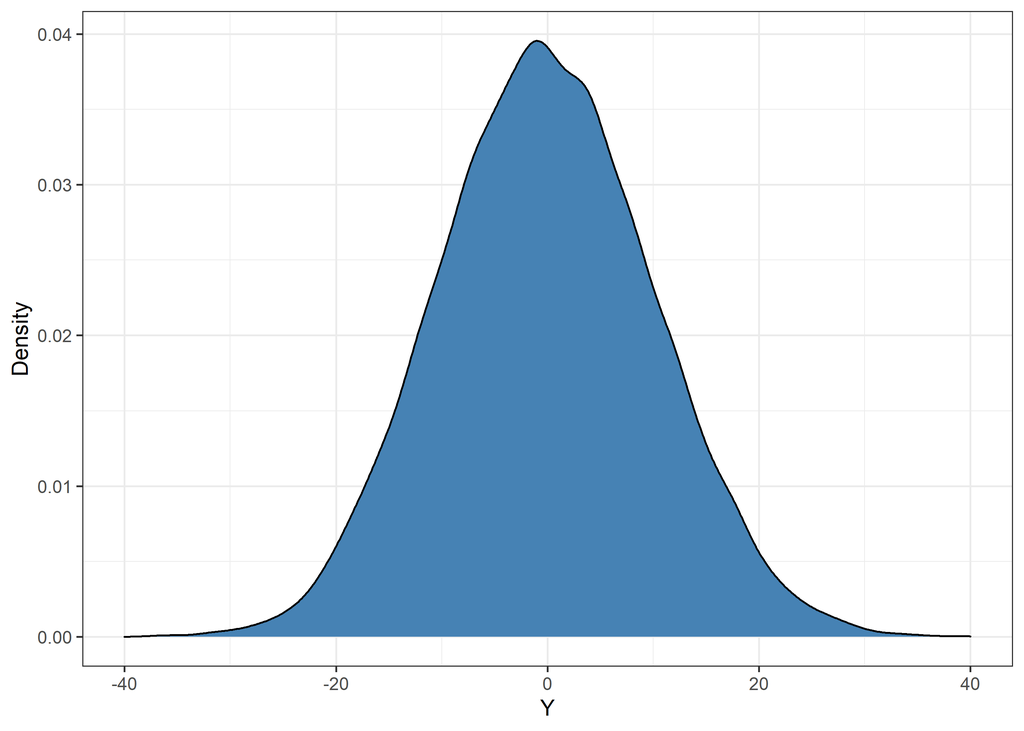

```r
# set seed
set.seed(11235813)

# generate the tibble
d <- tibble(
  sample_m = rnorm(n = 1e4, mean = 0, sd = 10),
  sample_s = rexp(n = 1e4, rate = 1),
  y = rnorm(n = 1e4, mean = sample_m, sd = sample_s),
)

#plot
d %>%
  ggplot(aes(x = y)) +
  geom_density(fill = "steelblue") +
  labs(x = "Y", y = "Density") +
  xlim(-40, 40)
```

## 2.2 4M2

Let’s take the model above and translate it to the `quap` formula.

```r
# set seed
set.seed(112358)

# formula list
q_formula <- alist(m = rnorm(1e4, 0, 10),
                   s = rexp(1e4, 1),
                   y = rnorm(1e4, m, sd))
```

This is it! We just wrap it around `alist`, which does not evaluate the functions but store them for use in `quap`.

## 2.3 4M3

We have a `quap` formula, let’s turn it into a mathematical model:

$$\begin{aligned}
y_i &\sim \text{Normal}(\mu, \sigma) \\
\mu &= \alpha + \beta x \\
\alpha &\sim \text{Normal}(0, 10) \\
\beta &\sim \text{Uniform}(0, 1) \\
\sigma &\sim \text{Exponential}(1)
\end{aligned}$$

## 2.4 4M4

Let’s first think about the measures we have. We have a student’s height, let’s call it $height$, and year, let’s call it $year$. We tie these two variables in the linear regression framework using a linear equation $height = \alpha + \beta*year$.

Here is the mathematical expression of these relationships:

$$\begin{aligned}
height_i &\sim \text{Normal}(\mu, \sigma) \\
\mu &= \alpha + \beta * year \\
\alpha &\sim \text{Normal}(170, 20) \\
\beta &\sim \text{LogNormal}(0, 1) \\
\sigma &\sim \text{Exponential}(1)
\end{aligned}$$
It is plausible to assume that $height$ is normally distributed. The priors for the $\alpha$ is chosen simply because 170 cm is (apparently) the average height of students in the US, and a standard deviation of 20 is relatively large but not too large to allow many Hobbits or giants.

I assumed a log normal distribution for $\beta$ to discard height shrinkage and allow small increases.

The exponential distribution for $\sigma$ is meant to narrow large deviations, for the same reason as above in terms of Hobbits or giants.

## 2.5 4M5

Before coming to this question, I already incorporated this thinking to my prior for the parameter $\beta$!

## 2.6 4M6

We now know that the variance, or $\sigma^2$, should be equal or less than 64 cm. This will lead me to revise my prior for $\sigma$. The main distribution I used before (exponential) makes it very unlikely that high values occur, but it’s still a theoretical possibility.

We can have two things: (a) we can add an upper bound to the specification above, using a conditional function that takes values according to the specified ranges, or (b) we can change the exponential prior to a uniform prior ($\sigma \sim \text{Uniform}(0, 8)$).

## 2.7 4M7

We are going to fit two models, one with centered variables and one uncentered variables. Let’s first set-up a few things.

```r
rm(list = ls()) # some clean-up
data(Howell1)
d <- Howell1
d <- d %>%
  filter(age >= 18) %>%
  mutate(cweight = weight - mean(weight),
         cheight = height - mean(height))
```

Cool! We are now going to use `quap` and fit two models.

```r
# set seed
set.seed(11235813)

# the model from the book, with centering
m_ycent <- quap(alist(
  height ~ dnorm(mu, sigma),
  mu <- a + b * cweight,
  a ~ dnorm(178, 20),
  b ~ dlnorm(0, 1),
  sigma ~ dunif(0, 50)
),
data = d)

# the new model, without the centering,
m_ncent <- quap(alist(
  height ~ dnorm(mu, sigma),
  mu <- a + b * weight,
  a ~ dnorm(178, 20),
  b ~ dlnorm(0, 1),
  sigma ~ dunif(0, 50)
),
data = d)
```

Nice, we have our models. Let’s compare the posteriors of these two models with a bunch of cool information.

```r
# let's look at the precis
precis(m_ycent)
```

```
##              mean         sd        5.5%       94.5%
## a     154.6015271 0.27032790 154.1694909 155.0335633
## b       0.9032836 0.04192677   0.8362766   0.9702907
## sigma   5.0722605 0.19119055   4.7667010   5.3778199
```

```r
precis(m_ncent)
```

```
##              mean         sd        5.5%       94.5%
## a     114.5333666 1.89775980 111.5003799 117.5663533
## b       0.8907538 0.04175826   0.8240161   0.9574916
## sigma   5.0727577 0.19125255   4.7670992   5.3784162
```

We see that $\beta$ values are nearly identical, but $\alpha$ changed. This is simply because, instead of estimating the average at $weight$, we now look at the $height$ when $weight$ is equal to 0.

```r
# variance-covariance matrices
round(diag(vcov(m_ycent)), 3)
```

```
##     a     b sigma
## 0.073 0.002 0.037
```

```r
round(diag(vcov(m_ncent)), 3)
```

```
##     a     b sigma
## 3.601 0.002 0.037
```

Looking at the variances, we see that the variance of $\alpha$ changed drastically, now that we do not estimate it through centered X.

```r
# let's see the correlations among parameters
round(cov2cor(vcov(m_ycent)), 3)
```

```
##           a      b  sigma
## a     1.000  0.000  0.001
## b     0.000  1.000 -0.003
## sigma 0.001 -0.003  1.000
```

```r
round(cov2cor(vcov(m_ncent)), 3)
```

```
##            a      b  sigma
## a      1.000 -0.990  0.026
## b     -0.990  1.000 -0.026
## sigma  0.026 -0.026  1.000
```

Finally, when we look at the correlations among parameters, we see that correlations were nearly 0 in the centered case, but when uncentered, we see a nearly full negative relationship between $\alpha$ and $\beta$.

Let’s now turn to the posterior predictions. First, draws:

```r
# posterior draws from the models

draws_ycent <- tidy_draws(m_ycent, n = 100)
draws_ncent <- tidy_draws(m_ncent, n = 100)

# predicted draws from the models

pdraw_ncent <- predicted_draws(m_ncent,
                               newdata = d,
                               draws = 1000) %>%
  group_by(.row) %>%
  mutate(lo_bound = HPDI(.prediction)[1],
         up_bound = HPDI(.prediction)[2])

pdraw_ycent <- predicted_draws(m_ycent,
                               newdata = d,
                               draws = 1000) %>%
  group_by(.row) %>%
  mutate(lo_bound = HPDI(.prediction)[1],
         up_bound = HPDI(.prediction)[2])
```

Good! We are up and running. It is time to plot the posterior predictive plots of the two models and compare.

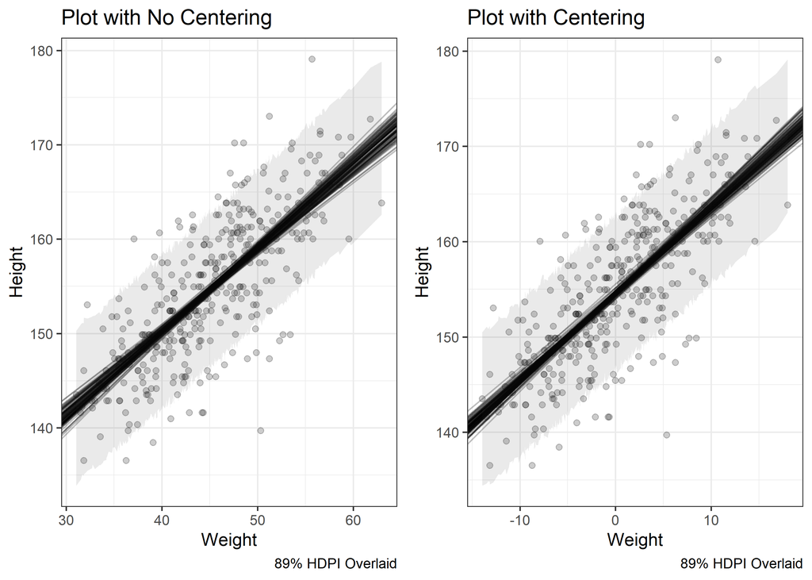

```r
# plot with no centering

plot_ncenter <- ggplot(draws_ncent) +
  geom_abline(aes(intercept = a, slope = b), alpha = .25) +
  geom_point(
    data = d,
    mapping = aes(x = weight, y = height),
    alpha = .2
  ) +
  labs(x = "Weight", y = "Height", title = "Plot with No Centering") +
  geom_ribbon(
    data = pdraw_ncent,
    mapping = aes(x = weight,
                  ymax = up_bound,
                  ymin = lo_bound),
    alpha = .1
  ) +
  labs(caption = "89% HDPI Overlaid")

# plot with centering

plot_wcenter <- ggplot(draws_ycent) +
  geom_abline(aes(intercept = a, slope = b), alpha = .25) +
  geom_point(
    data = d,
    mapping = aes(x = cweight, y = height),
    alpha = .2
  ) +
  labs(x = "Weight", y = "Height", title = "Plot with Centering") +
  geom_ribbon(
    data = pdraw_ycent,
    mapping = aes(x = cweight,
                  ymax = up_bound,
                  ymin = lo_bound),
    alpha = .1
  ) +
  labs(caption = "89% HDPI Overlaid")

grid.arrange(plot_ncenter, plot_wcenter, nrow = 1)
```

Neat! And well, slow…

## 2.8 4M8

OK, time for B-Splines. Let’s clear the environment and load the data.

```r
rm(list = ls())
data(cherry_blossoms)
d <- cherry_blossoms %>%
  drop_na(doy)
rm(cherry_blossoms) # tidy the room
precis(d)
```

```
##                   mean          sd      5.5%     94.5%       histogram
## year       1548.841596 304.1497740 1001.7200 1969.5700   ▁▂▂▃▅▃▇▇▇▇▇▇▁
## doy         104.540508   6.4070362   94.4300  115.0000        ▁▂▅▇▇▃▁▁
## temp          6.100356   0.6834104    5.1000    7.3662        ▁▃▅▇▃▁▁▁
## temp_upper    6.937560   0.8119865    5.8100    8.4177 ▁▃▅▇▅▃▂▁▁▁▁▁▁▁▁
## temp_lower    5.263545   0.7621943    4.1923    6.6277     ▁▁▁▂▅▇▃▁▁▁▁
```

Fine. I hate these kinds of data. As Werner Herzog says (not an exact quote), nature is not good, it is just meaningless agony.

Since we are asked to play with the number of knots and the priors, I am going to create a small function for later use.

```r
cherry_weirdos <- function(num_knots, std_prior) {
  # knots
  knot_list <-
    quantile(d$year, probs = seq(
      from = 0,
      to = 1,
      length.out = num_knots
    ))

  # basis functions
  basis <-
    bs(d$year,
       knots = knot_list[-c(1, num_knots)],
       degree = 3,
       intercept = T)

  # quap fit
  splines_fit <- quap(
    alist(
      D ~ dnorm(mu, sigma),
      mu <- a + B %*% w,
      a ~ dnorm(100, 10),
      w ~ dnorm(0, sigma_value),
      sigma ~ dexp(1)
    ),
    data = list(
      D = d$doy,
      B = basis,
      sigma_value = std_prior
    ),
    start = list(w = rep(0, ncol(basis)))
  )

  # intervals
  intervals <- splines_fit %>%
    link() %>% # I'm gonna use McElreath way here, simply because it's more simple
    as_tibble() %>%
    map_dfr(PI, prob = 0.97) %>%
    add_column(year = d$year) %>%
    left_join(d, by = "year") %>%
    rename(low = `2%`, up = `98%`)

  # plot
  ggplot(intervals,
         aes(x = year, y = doy)) +
    geom_point(col = "steelblue") +
    geom_ribbon(aes(ymin = low,
                    ymax = up)) +
    labs(x = "Year", y = "Day")
}
```

We are asked to change the number of knots. Here is a plot that shows that increasing the number of knots increases the “wiggly” (this is a scientific term!) nature of our data.

```r
wiggly_1 <- cherry_weirdos(15, 10)
wiggly_2 <- cherry_weirdos(30, 10)
```

```
## Caution, model may not have converged.
```

```
## Code 1: Maximum iterations reached.
```

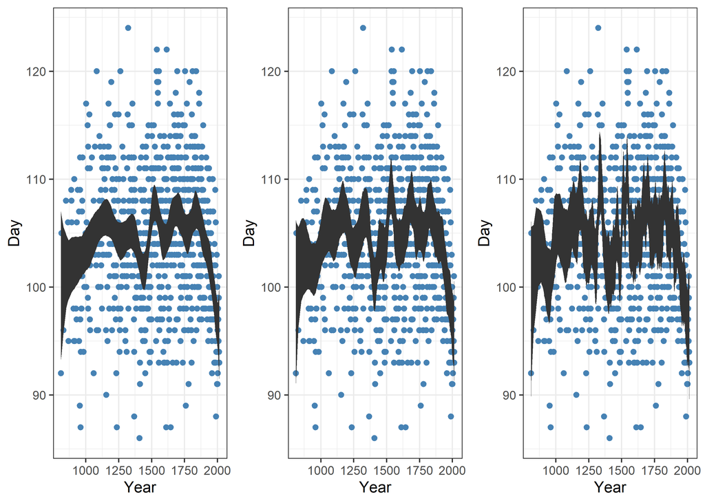

```r
wiggly_3 <- cherry_weirdos(60, 10)

grid.arrange(wiggly_1, wiggly_2, wiggly_3, nrow = 1)
```

We are also asked to vary the standard deviation of the prior. Let’s do that!

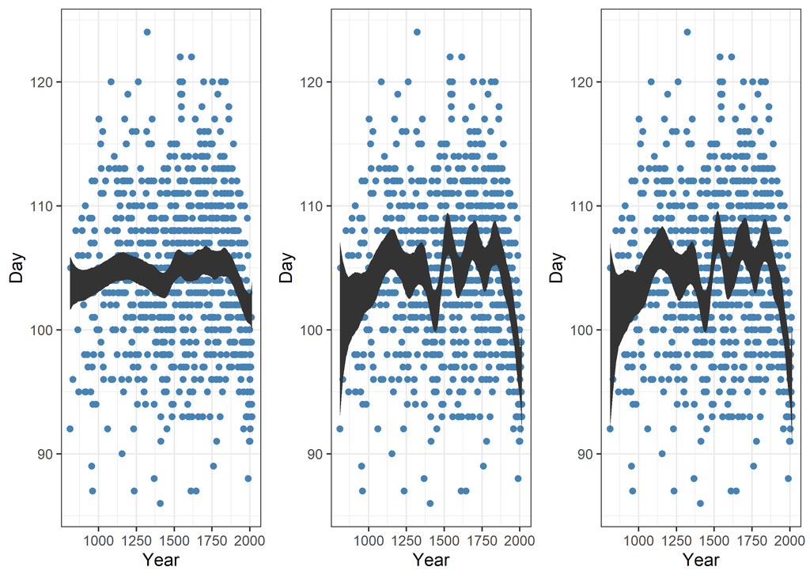

```r
wiggly_1 <- cherry_weirdos(15, 1)
wiggly_2 <- cherry_weirdos(15, 10)
wiggly_3 <- cherry_weirdos(15, 50)

grid.arrange(wiggly_1, wiggly_2, wiggly_3, nrow = 1)
```

These are basically affecting the wiggly nature of the data!

Neat!